# Connect your NAS anywhere using `Casa OS` and `Tailscale`

- This is a step-by-step guide showing how to add a sleek web interface (`CasaOS`) to your `NAS` and make it accessible over the internet using `Tailscale`.
- This way, you can manage and access your `NAS` from anywhere—without messy port forwarding or complicated VPN setups. Let’s dive in!

## Part 1: Install CasaOS

### Why CasaOS?

- CasaOS is an open-source, simple home-server OS that gives you an attractive, user-friendly dashboard to manage apps, storage, and more.
- It runs on top of your existing Ubuntu system, so you can keep all the stuff you’ve set up while getting a neat interface for day-to-day tasks.

### Prerequisites

- An Ubuntu-based machine (your old laptop serving as the `NAS`).
- `Docker` installed (`CasaOS` uses `Docker` under the hood).
- Check if Docker is installed:

  ```
  docker --version
  ```

- If not installed, follow Docker’s official installation guide or just run:

  ```
  sudo apt update
  sudo apt install docker.io
  sudo systemctl start docker
  sudo systemctl enable docker
  ```

### Installing CasaOS

- Once the script finishes, you should see instructions on how to access CasaOS’s web interface. Usually, you can head to:

  ```
  http://<Your NAS IP>:80
  ```

- (For example, http://192.168.1.100 if that’s your `NAS` IP.)

### First-Time Setup of CasaOS

1. Open the web interface in your browser (on the same network, or eventually via `Tailscale`).
2. Create an account or log in (depending on the `CasaOS` version, you might be prompted to set up an admin account).
3. Explore the dashboard: You’ll see sections for `Files`, `Apps`, `Settings`, etc.

[figure not shown]

## Part 2: Expose Your NAS Over the Internet Using `Tailscale`

### Why Tailscale?

- **No port forwarding required**: `Tailscale` creates a secure, peer-to-peer virtual network.
- **Simple setup**: A single command to install, then log in with your `Google`, `Microsoft`, or `GitHub` account.
- **Secure**: Everything is encrypted; you’re only exposing your `NAS` to your `Tailscale` network, not the entire internet.

### Install Tailscale on Your NAS

1. Update your package list:

   ```
   sudo apt update
   ```

2. Install Tailscale (for Ubuntu 20.04 and later):

   ```
   curl -fsSL https://tailscale.com/install.sh | sh
   ```

### Start Tailscale and Sign In

1. Authenticate your `NAS` to your `Tailscale` account:
   1. This command opens a browser window (or gives you a URL) asking you to log in to `Tailscale`.
   2. Once logged in, your `NAS` will appear in your `Tailscale` admin console.

   ```
   sudo tailscale up
   ```

2. Enable and start `Tailscale`:

   ```
   sudo systemctl enable tailscaled
   sudo systemctl start tailscaled
   ```

## Accessing Your NAS via Tailscale

1. Install `Tailscale` into another devices (e.g. iphone), then you should able to see your `NAS`

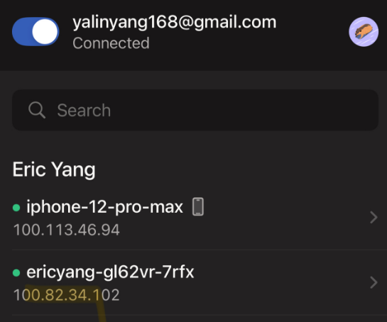

2. When click in, You should see something like `100.xxx.xxx.xxx` — that’s your NAS’s `Tailscale` IP address.

[figure not shown]

- You can always goto https://login.tailscale.com/admin/machines to check your `Tailscale` device list

## Final Wrap-Up

- `CasaOS` gives your `NAS` a slick, friendly dashboard to manage apps and files.
- `Tailscale` creates a secure, hassle-free way to access your NAS from anywhere in the world.

With these two tools combined, your old laptop becomes a powerful, user-friendly, and remotely accessible `NAS` solution. And you did it all without the headaches of port forwarding or clunky VPNs!

Happy remote NAS-ing! If you ever want to take it further, you could set up other containers in CasaOS, schedule automated backups, or explore Tailscale features like MagicDNS to use a personalized domain. Enjoy your new all-in-one storage system!

2025-09-18 2025-09-18